# MSDS 6372 Project 1 Objective 2

Jaclyn A Coate

1/22/2020

```r
library(tidyverse)
library(mice)
library(skimr)
library(corrplot)
library(car)
library(ISLR)
library(ggplot2)
library(gridExtra)
```

# Objective 1:

## Question of Interest: what variables are used to predict price of a NYC Airbnb

```r
nycraw <- read.csv("https://raw.githubusercontent.com/JaclynCoate/6372_Project/master/AB_NYC_2019.csv", header = TRUE, strip.white=TRUE)
head(nycraw)
```

```
##     id                                             name host_id
## 1 2539               Clean & quiet apt home by the park    2787
## 2 2595                            Skylit Midtown Castle    2845
## 3 3831                  Cozy Entire Floor of Brownstone    4869
## 4 5022 Entire Apt: Spacious Studio/Loft by central park    7192
## 5 5099        Large Cozy 1 BR Apartment In Midtown East    7322
## 6 5121                                  BlissArtsSpace!    7356
##     host_name neighbourhood_group      neighbourhood latitude longitude
## 1        John            Brooklyn         Kensington 40.64749 -73.97237
## 2    Jennifer           Manhattan            Midtown 40.75362 -73.98377
## 3 LisaRoxanne            Brooklyn       Clinton Hill 40.68514 -73.95976
## 4       Laura           Manhattan        East Harlem 40.79851 -73.94399
## 5       Chris           Manhattan        Murray Hill 40.74767 -73.97500
## 6       Garon            Brooklyn Bedford-Stuyvesant 40.68688 -73.95596
##         room_type price minimum_nights number_of_reviews last_review
## 1    Private room   149              1                 9    10/19/18
## 2 Entire home/apt   225              1                45     5/21/19
## 3 Entire home/apt    89              1               270      7/5/19
## 4 Entire home/apt    80             10                 9    11/19/18
## 5 Entire home/apt   200              3                74     6/22/19
## 6    Private room    60             45                49     10/5/17
##   reviews_per_month calculated_host_listings_count availability_365
## 1              0.21                              6              365
## 2              0.38                              2              355
## 3              4.64                              1              194
## 4              0.10                              1                0
## 5              0.59                              1              129
## 6              0.40                              1                0
```

```r
str(nycraw)
```

```
## 'data.frame':    34464 obs. of  16 variables:
##  $ id                            : int  2539 2595 3831 5022 5099 5121 5178 5203 5238 5295 ...
##  $ name                          : Factor w/ 34000 levels ""," Private 1 bdrm Lefferts Gr, BK apt",..: 8990 27105 11178 13776 17775 5839 17808 11099 12643 3931 ...
##  $ host_id                       : int  2787 2845 4869 7192 7322 7356 8967 7490 7549 7702 ...
##  $ host_name                     : Factor w/ 9124 levels ""," Valéria",..: 4017 3840 4984 4754 1544 2840 7735 5519 958 4836 ...
##  $ neighbourhood_group           : Factor w/ 5 levels "Bronx","Brooklyn",..: 2 3 2 3 3 2 3 3 3 3 ...
##  $ neighbourhood                 : Factor w/ 218 levels "Allerton","Arden Heights",..: 108 127 42 62 137 14 95 201 36 201 ...
##  $ latitude                      : num  40.6 40.8 40.7 40.8 40.7 ...
##  $ longitude                     : num  -74 -74 -74 -73.9 -74 ...
##  $ room_type                     : Factor w/ 3 levels "Entire home/apt",..: 2 1 1 1 1 2 2 2 1 1 ...
##  $ price                         : int  149 225 89 80 200 60 79 79 150 135 ...
##  $ minimum_nights                : int  1 1 1 10 3 45 2 2 1 5 ...
##  $ number_of_reviews             : int  9 45 270 9 74 49 430 118 160 53 ...
##  $ last_review                   : Factor w/ 908 levels "1/1/17","1/1/18",..: 113 575 775 175 671 144 677 745 716 671 ...
##  $ reviews_per_month             : num  0.21 0.38 4.64 0.1 0.59 0.4 3.47 0.99 1.33 0.43 ...
##  $ calculated_host_listings_count: int  6 2 1 1 1 1 1 1 4 1 ...
##  $ availability_365              : int  365 355 194 0 129 0 220 0 188 6 ...
```

## EDA to determine type of multiple linear regression to perform

#### Removing logically irrelevant variables

```r
#Dropping logical irrelevant variables: "id", "name", "host_id", "host_name", "last_reiview", "latitude", "longitude", "neighborhood","availability_365"
nyc2 <- select(nycraw, -c("id", "name", "host_id", "host_name", "last_review", "latitude", "longitude", "neighbourhood","availability_365"))
head(nyc2)
```

```
##   neighbourhood_group       room_type price minimum_nights
## 1            Brooklyn    Private room   149              1
## 2           Manhattan Entire home/apt   225              1
## 3            Brooklyn Entire home/apt    89              1
## 4           Manhattan Entire home/apt    80             10
## 5           Manhattan Entire home/apt   200              3
## 6            Brooklyn    Private room    60             45
##   number_of_reviews reviews_per_month calculated_host_listings_count
## 1                 9              0.21                              6
## 2                45              0.38                              2
## 3               270              4.64                              1
## 4                 9              0.10                              1
## 5                74              0.59                              1
## 6                49              0.40                              1
```

#### Dependent Variable Check

- Checking on dependent variable range to make sure if there are zero’s to remove. It would not be free to stay in NYC.

```r
nyc2 <- nyc2[!(nyc2$price==0),]
invisible(view(nyc2))
```

#### NA Evaluation and Drop

```r
#Checking for NAs
md.pattern(nyc2)
```

```
##  /\     /\
## {  `---'  }
## {  O   O  }
## ==>  V <==  No need for mice. This data set is completely observed.
##  \  \|/  /
##   `-----'
```

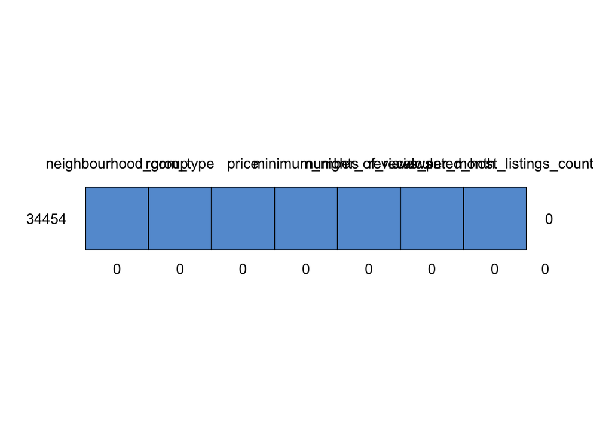

```
##       neighbourhood_group room_type price minimum_nights number_of_reviews
## 34454                   1         1     1              1                 1
##                         0         0     0              0                 0
##       reviews_per_month calculated_host_listings_count
## 34454                 1                              1 0
##                       0                              0 0
```

```r
nrow(nyc2)
```

```
## [1] 34454
```

```r
#Drop NAs that are present
nyc3 <- na.omit(nyc2)
#Confirming NA drop
nrow(nyc3)
```

```
## [1] 34454
```

#### Zero variance variable check - all show variance so remain in model

```r
#Results show no zero variance variables, leave in all
skim(nyc3)
```

```
## Skim summary statistics
##  n obs: 34454
##  n variables: 7
##
## ── Variable type:factor ────────────────────────────────────────────────────────
##             variable missing complete     n n_unique
##  neighbourhood_group       0    34454 34454        5
##            room_type       0    34454 34454        3
##                                   top_counts ordered
##  Bro: 14552, Man: 14436, Que: 4304, Bro: 854   FALSE
##      Ent: 17919, Pri: 15752, Sha: 783, NA: 0   FALSE
##
## ── Variable type:integer ───────────────────────────────────────────────────────
##                        variable missing complete     n   mean     sd p0
##  calculated_host_listings_count       0    34454 34454   5.56  27.76  1
##                  minimum_nights       0    34454 34454   5.78  15.48  1
##               number_of_reviews       0    34454 34454  32.34  50.23  1
##                           price       0    34454 34454 140.73 167.84 10
##  p25 p50 p75  p100     hist
##    1   1   2   327 ▇▁▁▁▁▁▁▁
##    2   2   4   999 ▇▁▁▁▁▁▁▁
##    4  12  39   629 ▇▁▁▁▁▁▁▁
##   68 100 170 10000 ▇▁▁▁▁▁▁▁
##
## ── Variable type:numeric ───────────────────────────────────────────────────────
##           variable missing complete     n mean   sd   p0 p25  p50  p75
##  reviews_per_month       0    34454 34454 1.53 1.72 0.02 0.3 0.94 2.27
##  p100     hist
##  58.5 ▇▁▁▁▁▁▁▁
```

#### Storing all categorical variables as factors

```r
#Storing categorical variables as factors
skim(nyc3)
```

```
## Skim summary statistics
##  n obs: 34454
##  n variables: 7
##
## ── Variable type:factor ────────────────────────────────────────────────────────
##             variable missing complete     n n_unique
##  neighbourhood_group       0    34454 34454        5
##            room_type       0    34454 34454        3
##                                   top_counts ordered
##  Bro: 14552, Man: 14436, Que: 4304, Bro: 854   FALSE
##      Ent: 17919, Pri: 15752, Sha: 783, NA: 0   FALSE
##
## ── Variable type:integer ───────────────────────────────────────────────────────
##                        variable missing complete     n   mean     sd p0
##  calculated_host_listings_count       0    34454 34454   5.56  27.76  1
##                  minimum_nights       0    34454 34454   5.78  15.48  1
##               number_of_reviews       0    34454 34454  32.34  50.23  1
##                           price       0    34454 34454 140.73 167.84 10
##  p25 p50 p75  p100     hist
##    1   1   2   327 ▇▁▁▁▁▁▁▁
##    2   2   4   999 ▇▁▁▁▁▁▁▁
##    4  12  39   629 ▇▁▁▁▁▁▁▁
##   68 100 170 10000 ▇▁▁▁▁▁▁▁
##
## ── Variable type:numeric ───────────────────────────────────────────────────────
##           variable missing complete     n mean   sd   p0 p25  p50  p75
##  reviews_per_month       0    34454 34454 1.53 1.72 0.02 0.3 0.94 2.27
##  p100     hist
##  58.5 ▇▁▁▁▁▁▁▁
```

#### Checking for Multicollinearity

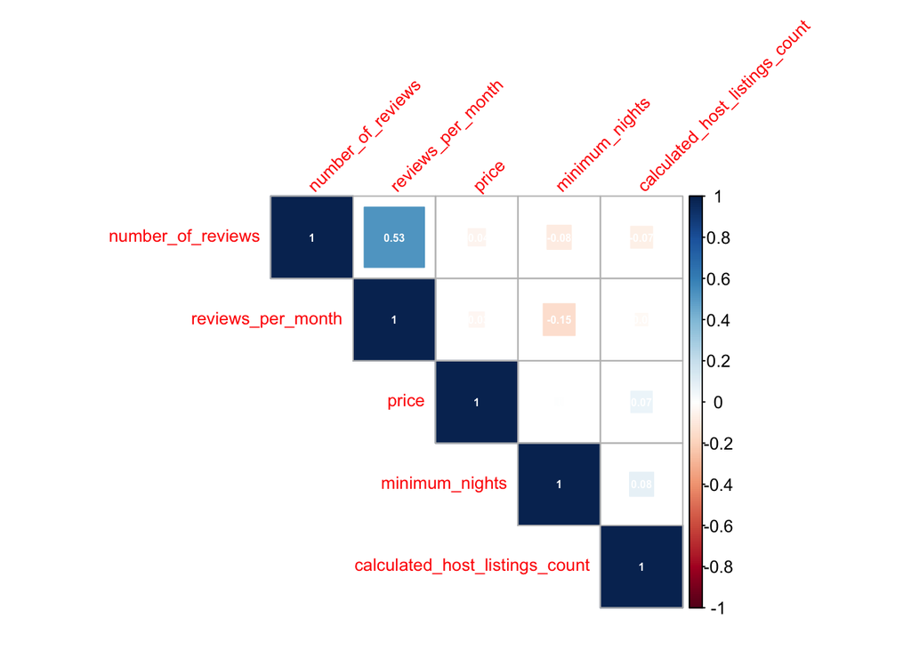

```r
corrNYC <- nyc3
#Table numeric variables
corrNYCTable <- corrNYC %>% keep(is.numeric) %>% cor %>% view
#Plot numeric variables v numeric variables
corrNYC %>% keep(is.numeric) %>% cor %>% corrplot("upper", addCoef.col = "white", number.digits = 2, number.cex = 0.5, method="square", order="hclust", tl.srt=45, tl.cex = 0.8)
```

```r
invisible(view(corrNYCTable))
```

```r
#Removing reviews_per_month due to high correlation of is and number_of_reviews
nyc4 <- select(nyc3, -c("reviews_per_month"))
```

#### Summary Review of Data Set

```r
summary(nyc4)
```

```
##     neighbourhood_group           room_type         price
##  Bronx        :  854    Entire home/apt:17919   Min.   :   10.0
##  Brooklyn     :14552    Private room   :15752   1st Qu.:   68.0
##  Manhattan    :14436    Shared room    :  783   Median :  100.0
##  Queens       : 4304                            Mean   :  140.7
##  Staten Island:  308                            3rd Qu.:  170.0
##                                                 Max.   :10000.0
##  minimum_nights    number_of_reviews calculated_host_listings_count
##  Min.   :  1.000   Min.   :  1.00    Min.   :  1.000
##  1st Qu.:  2.000   1st Qu.:  4.00    1st Qu.:  1.000
##  Median :  2.000   Median : 12.00    Median :  1.000
##  Mean   :  5.777   Mean   : 32.34    Mean   :  5.558
##  3rd Qu.:  4.000   3rd Qu.: 39.00    3rd Qu.:  2.000
##  Max.   :999.000   Max.   :629.00    Max.   :327.000
```

#### Removing outliers from minimum nights stay

- Anything over 365 is more than a year and would be improbable
- Removing any minimum nights metric over 365

```r
nyc4 <- nyc4[!(nyc4$minimum_nights > 365),]
invisible(view(nyc4))
```

#### Examining VIFs

- The below results show us there is no need to remove any variables

```r
full.model<-lm(price~.,data=nyc4)  # . means all variable not mpg
vif(full.model)[,3]^2
```

```
##            neighbourhood_group                      room_type
##                       1.011167                       1.018374
##                 minimum_nights              number_of_reviews
##                       1.029835                       1.014416
## calculated_host_listings_count
##                       1.031679
```

```r
alias(lm(price~.,data=nyc4))
```

```
## Model :
## price ~ neighbourhood_group + room_type + minimum_nights + number_of_reviews +
##     calculated_host_listings_count
```

# Question 2

## 2-Way ANOVA Analysis

- In completing this project with the tools learned in Unit 3 - we will perform a 2-Way ANOVA analysis.

```r
nyc.anova <- nyc4 %>% select(-c("number_of_reviews", "calculated_host_listings_count", "minimum_nights"))
head(nyc.anova)
```

```
##   neighbourhood_group       room_type price
## 1            Brooklyn    Private room   149
## 2           Manhattan Entire home/apt   225
## 3            Brooklyn Entire home/apt    89
## 4           Manhattan Entire home/apt    80
## 5           Manhattan Entire home/apt   200
## 6            Brooklyn    Private room    60
```

```r
invisible(view(nyc.anova))
```

#### Unbalanced Data

- In reviewing the data we see unbalanced data between the Shared room, Private room, and Entire home/apt indepednet variable levels
- Comapring a shared room leve to a private room or home seems logically irrelevent
- Removing shared room variable
- By removing this leve this model will no longer used for a shared room level of the room_type variable
  - Include this in the conclusion/caveat in scope of inference

```r
#Reviewing data levels of room_types
nyc.home <- nyc.anova[(nyc.anova$room_type=="Entire home/apt"),]
nrow(nyc.home)
```

```
## [1] 17916
```

```r
nyc.private <- nyc.anova[(nyc.anova$room_type=="Private room"),]
nrow(nyc.private)
```

```
## [1] 15751
```

```r
nyc.shared <- nyc.anova[(nyc.anova$room_type=="Shared room"),]
nrow(nyc.shared)
```

```
## [1] 783
```

```r
#Making final data set with only Private room & Entire home/apt
nyc.anova <- nyc.anova[!(nyc.anova$room_type=="Shared room"),]
invisible(nyc.anova)
```

#### Summary Statistics Table

- Creating Mean, SD, SE, Min, Max, and IQR
- Table of graphable statistics

```r
#Attaching the data set
attach(nyc.anova)
#Creating a function
nycsummary<-function(x){
  result<-c(length(x),mean(x),sd(x),sd(x)/sqrt(length(x)), min(x), max(x), IQR(x))
  names(result)<-c("N","Mean","SD","SE","Min","Max","IQR")
  return(result)
}
#Creating a summary stats table
nycsumstats<-aggregate(price~neighbourhood_group*room_type,data=nyc.anova,nycsummary)
nycsumstats<-cbind(nycsumstats[,1:2],nycsumstats[,-(1:2)])
nycsumstats
```

```
##    neighbourhood_group       room_type    N      Mean        SD        SE
## 1                Bronx Entire home/apt  303 120.90759  76.90631 4.4181522
## 2             Brooklyn Entire home/apt 7249 171.17009 186.37778 2.1890470
## 3            Manhattan Entire home/apt 8607 231.33124 226.06540 2.4367344
## 4               Queens Entire home/apt 1612 140.35360  99.16677 2.4699244
## 5        Staten Island Entire home/apt  145 118.80000  58.50411 4.8585017
## 6                Bronx    Private room  509  57.24754  27.06709 1.1997278
## 7             Brooklyn    Private room 7030  72.38435 100.53211 1.1990220
## 8            Manhattan    Private room 5509 104.66146  81.70022 1.1007453
## 9               Queens    Private room 2545  65.06876  39.19439 0.7769266
## 10       Staten Island    Private room  158  57.65190  27.66610 2.2009967
##    Min   Max    IQR
## 1   35   670  60.00
## 2   10 10000  91.00
## 3   10  8500 110.00
## 4   10  2600  75.00
## 5   48   300  65.00
## 6   21   300  25.00
## 7   10  7500  30.00
## 8   10  1599  50.00
## 9   10   900  28.00
## 10  20   235  32.75
```

#### Summary Statistics Graph

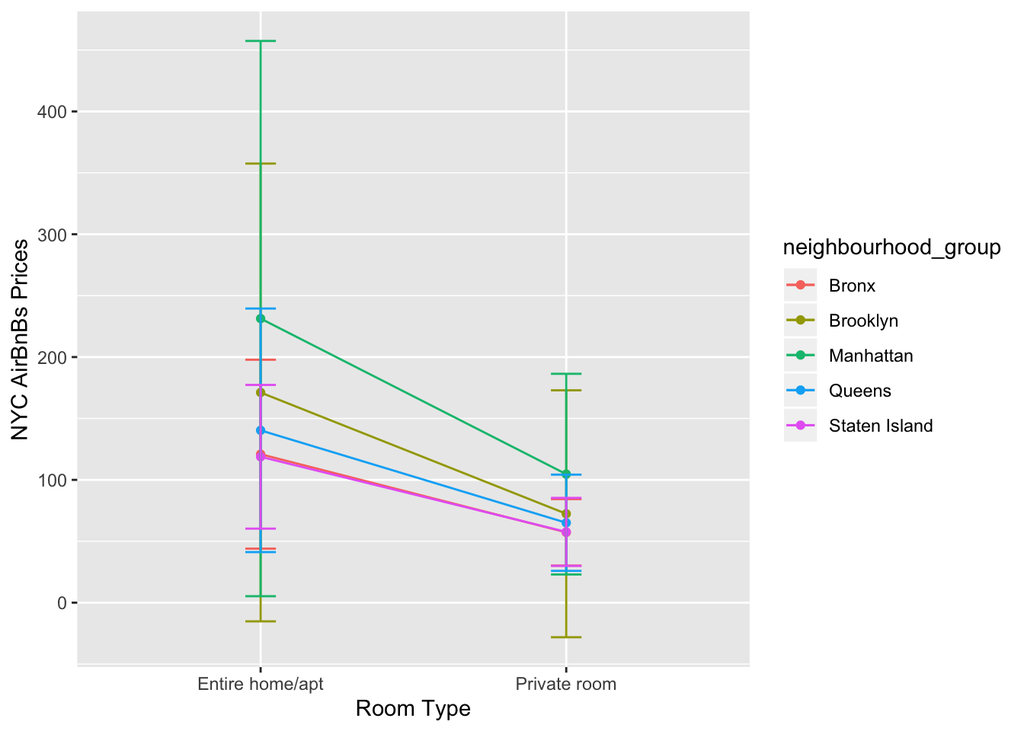

```r
ggplot(nycsumstats,aes(x=room_type,y=Mean,group=neighbourhood_group,colour=neighbourhood_group))+
  ylab("NYC AirBnBs Prices")+xlab("Room Type")+
  geom_line()+
  geom_point()+
  geom_errorbar(aes(ymin=Mean-SD,ymax=Mean+SD),width=.1)
```

#### Nonadditive 2-Way ANOVA

- QQ Plot for assumption assessment
  - Show a curve, needs transformation

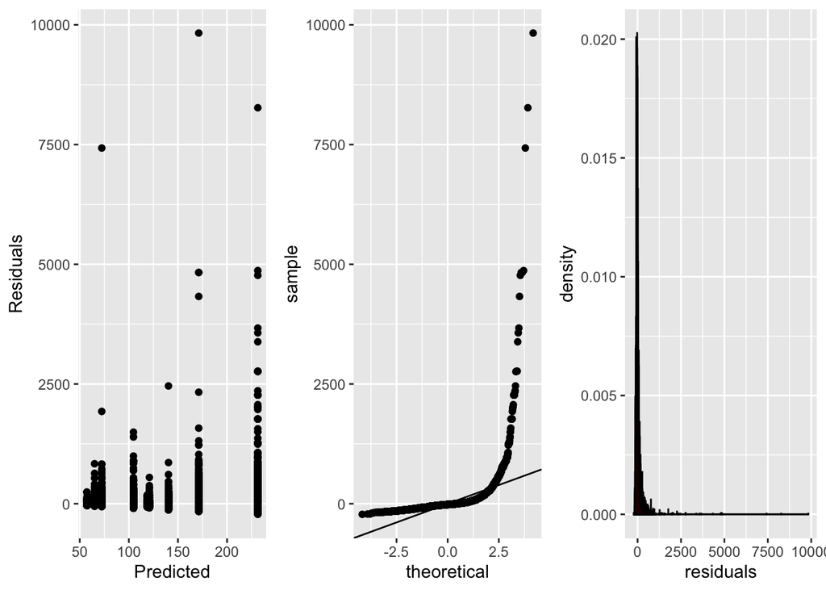

```r
#The following code fits the nonadditive two way anova model and then produces the first the main residual diagnostics for assumption checking
nyc.model.fit<-aov(price~neighbourhood_group+room_type+neighbourhood_group:room_type,data=nyc.anova)

nyc.fits <- data.frame(fitted.values=nyc.model.fit$fitted.values,residuals=nyc.model.fit$residuals)

#Reisudals vs Fitted
nyc.plot1 <- ggplot(nyc.fits, aes(x=fitted.values,y=residuals))+ylab("Residuals")+
  xlab("Predicted")+geom_point()
#QQ Plot of residuals #Note the diagonal abline is only good for qqplots of normal data
nyc.plot2 <- ggplot(nyc.fits,aes(sample=residuals))+
  stat_qq()+geom_abline(intercept=mean(nyc.fits$residuals), slope = sd(nyc.fits$residuals))
#Histograms of residuals
nyc.plot3 <- ggplot(nyc.fits, aes(x=residuals)) +
  geom_histogram(aes(y=..density..),binwidth=1,color="black", fill="gray")+
  geom_density(alpha=.1, fill="red")
#Grid of all 3 graphs above
grid.arrange(nyc.plot1, nyc.plot2, nyc.plot3, ncol=3)
```

#### Log transformation on price

```r
#Cannot log zero values, must remove from price variable
nyc.anova <- nyc.anova[!(nyc.anova$price == 0),]
#Auto3 <- Auto[!(Auto$cylinders == 3),]
#Transforming price to logged variable
nyc.log.anova <- nyc.anova %>% mutate(lprice=log(price))
#view(nyc.final)
```

#### Assumptions check on log transformation of price

- Equal variances: there is some slight variation of variances but this will suffice in order to move forward
- QQ Plot: there is still some slight departure from normality, but again this is acceptable to move forward with our model
- DON’T FORGET TO MENTION CLT - Central Limit Theorum

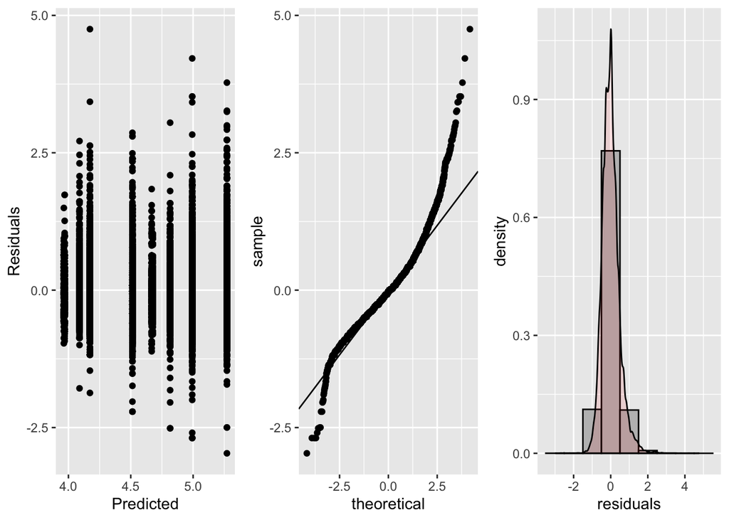

```r
nyc.model.fit.log<-aov(lprice~neighbourhood_group+room_type+neighbourhood_group:room_type,data=nyc.log.anova)

nyc.fits.log <- data.frame(fitted.values=nyc.model.fit.log$fitted.values,residuals=nyc.model.fit.log$residuals)

#Reisudals vs Fitted
nyc.logplot1 <- ggplot(nyc.fits.log, aes(x=fitted.values,y=residuals))+ylab("Residuals")+
  xlab("Predicted")+geom_point()
#QQ Plot of residuals #Note the diagonal abline is only good for qqplots of normal data
nyc.logplot2 <- ggplot(nyc.fits.log,aes(sample=residuals))+
  stat_qq()+geom_abline(intercept=mean(nyc.fits.log$residuals), slope = sd(nyc.fits.log$residuals))
#Histograms of residuals
nyc.logplot3 <- ggplot(nyc.fits.log, aes(x=residuals)) +
  geom_histogram(aes(y=..density..),binwidth=1,color="black", fill="gray")+
  geom_density(alpha=.1, fill="red")
#Grid of all 3 graphs above
grid.arrange(nyc.logplot1, nyc.logplot2, nyc.logplot3, ncol=3)
```

#### Outliers

- Since there are not singular points that are aggressively skewing the data, these outliers aren’t considered unique or affecting the model in a way that would not be logical.
- Choose to leave all low and high end metrics since the model should take these into account

#### Type III F-test table

```r
Anova(nyc.model.fit.log,type=3)
```

```
## Anova Table (Type III tests)
##
## Response: lprice
##                               Sum Sq    Df   F value    Pr(>F)
## (Intercept)                   6601.7     1 29773.741 < 2.2e-16 ***
## neighbourhood_group            548.1     4   617.997 < 2.2e-16 ***
## room_type                       92.5     1   417.142 < 2.2e-16 ***
## neighbourhood_group:room_type   11.9     4    13.391 6.619e-11 ***
## Residuals                     7462.7 33657
## ---
## Signif. codes:  0 '***' 0.001 '**' 0.01 '*' 0.05 '.' 0.1 ' ' 1
```

#### Multiple Test Technique: Tukey-Kramer

- From the F-test table we can see that all current variables are statistically significnat at the 0.05 alpha level
- Move forward with the Tukey-Kramer to discover what factors and/or combinations contribute to predicting the price of a NYC AirBnB

```r
nyc.anova.diff <- TukeyHSD(nyc.model.fit.log,"neighbourhood_group:room_type", conf.level = .95)
nyc.anova.diff
```

```
##   Tukey multiple comparisons of means
##     95% family-wise confidence level
##
## Fit: aov(formula = lprice ~ neighbourhood_group + room_type + neighbourhood_group:room_type, data = nyc.log.anova)
##
## $`neighbourhood_group:room_type`
##                                                                  diff
## Brooklyn:Entire home/apt-Bronx:Entire home/apt            0.325259028
## Manhattan:Entire home/apt-Bronx:Entire home/apt           0.603543911
## Queens:Entire home/apt-Bronx:Entire home/apt              0.148054935
## Staten Island:Entire home/apt-Bronx:Entire home/apt       0.009552579
## Bronx:Private room-Bronx:Entire home/apt                 -0.697830562
## Brooklyn:Private room-Bronx:Entire home/apt              -0.495252769
## Manhattan:Private room-Bronx:Entire home/apt             -0.154455798
## Queens:Private room-Bronx:Entire home/apt                -0.578839521
## Staten Island:Private room-Bronx:Entire home/apt         -0.704507541
## Manhattan:Entire home/apt-Brooklyn:Entire home/apt        0.278284884
## Queens:Entire home/apt-Brooklyn:Entire home/apt          -0.177204093
## Staten Island:Entire home/apt-Brooklyn:Entire home/apt   -0.315706449
## Bronx:Private room-Brooklyn:Entire home/apt              -1.023089590
## Brooklyn:Private room-Brooklyn:Entire home/apt           -0.820511797
## Manhattan:Private room-Brooklyn:Entire home/apt          -0.479714825
## Queens:Private room-Brooklyn:Entire home/apt             -0.904098548
## Staten Island:Private room-Brooklyn:Entire home/apt      -1.029766569
## Queens:Entire home/apt-Manhattan:Entire home/apt         -0.455488977
## Staten Island:Entire home/apt-Manhattan:Entire home/apt  -0.593991332
## Bronx:Private room-Manhattan:Entire home/apt             -1.301374474
## Brooklyn:Private room-Manhattan:Entire home/apt          -1.098796681
## Manhattan:Private room-Manhattan:Entire home/apt         -0.757999709
## Queens:Private room-Manhattan:Entire home/apt            -1.182383432
## Staten Island:Private room-Manhattan:Entire home/apt     -1.308051452
## Staten Island:Entire home/apt-Queens:Entire home/apt     -0.138502356
## Bronx:Private room-Queens:Entire home/apt                -0.845885497
## Brooklyn:Private room-Queens:Entire home/apt             -0.643307704
## Manhattan:Private room-Queens:Entire home/apt            -0.302510732
## Queens:Private room-Queens:Entire home/apt               -0.726894455
## Staten Island:Private room-Queens:Entire home/apt        -0.852562476
## Bronx:Private room-Staten Island:Entire home/apt         -0.707383141
## Brooklyn:Private room-Staten Island:Entire home/apt      -0.504805348
## Manhattan:Private room-Staten Island:Entire home/apt     -0.164008377
```

[output cut: 135 more lines]

```
## Bronx:Private room-Staten Island:Entire home/apt         0.0000000
## Brooklyn:Private room-Staten Island:Entire home/apt      0.0000000
## Manhattan:Private room-Staten Island:Entire home/apt     0.0014305
## Queens:Private room-Staten Island:Entire home/apt        0.0000000
## Staten Island:Private room-Staten Island:Entire home/apt 0.0000000
## Brooklyn:Private room-Bronx:Private room                 0.0000000
## Manhattan:Private room-Bronx:Private room                0.0000000
## Queens:Private room-Bronx:Private room                   0.0000086
## Staten Island:Private room-Bronx:Private room            1.0000000
## Manhattan:Private room-Brooklyn:Private room             0.0000000
## Queens:Private room-Brooklyn:Private room                0.0000000
## Staten Island:Private room-Brooklyn:Private room         0.0000015
## Queens:Private room-Manhattan:Private room               0.0000000
## Staten Island:Private room-Manhattan:Private room        0.0000000
## Staten Island:Private room-Queens:Private room           0.0377400
```

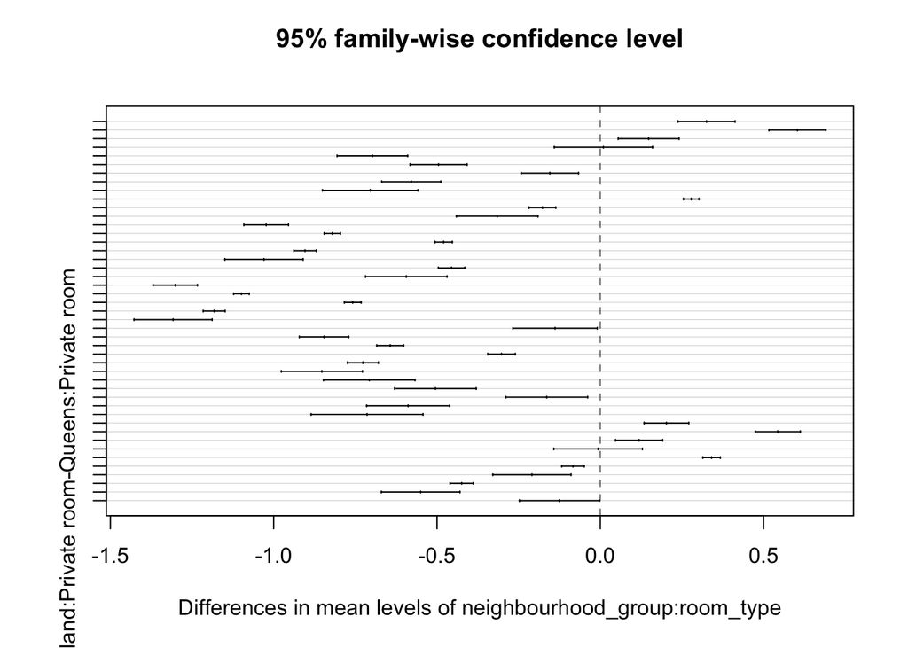

```r
plot(TukeyHSD(nyc.model.fit.log,"neighbourhood_group:room_type", conf.level = .95))
```